# 第11回 標準誤差・t 値・仮説検定・信頼区間

経済データ入門

第11回

標準誤差・t 値・仮説  
検定・信頼区間

傾きの標準誤差を測って、偶然かどうかを判定する

経済データ入門

第11回 — Topic01

標準誤差

その傾き、どこまで信じてよい？

## 前回の振り返り

前回のポイント 第10回「単回帰・最小二乗法・決定係数」

Q: 5 人と 36 年に引いた線から、何が分かったか

- **5 人**：線 12 − 2x。バイトが 1 日多いと、自習の見込みが 2 時間短い
- **36 年**：傾き −0.859。期間を変えると、傾きも決定係数も変わった
- **出力表**：係数と重決定 R2 は読んだ。まだ読んでいない列がある

今日は、その傾きをどこまで信じてよいかを測る

## この回の道のりと「5人」シート

1

標準誤差

演習 11-1

9 年の標準誤差

2

t 値

演習 11-2

9 年の t 値

3

仮説検定

演習 11-3

7 年の仮説検定

4

信頼区間

演習 11-4

7 年の信頼区間

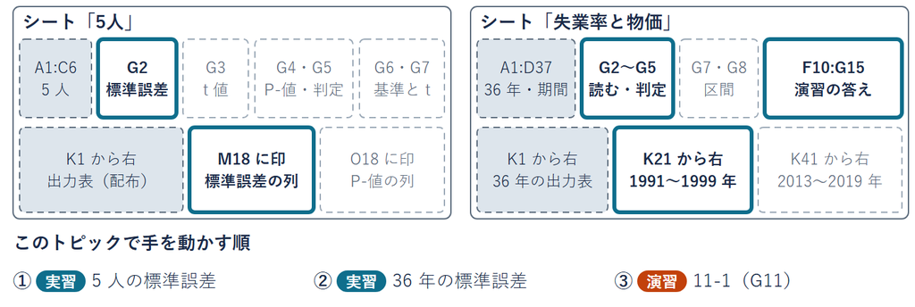

置き場は lec11-exercise.xlsx の 2 枚。出力表は両方の K1 から右に配ってある

## 別の 5 人の傾き

同じアンケートを、別の 5 人に取ったら  
同じ線 12 − 2x になるか

- **いまの道具**：5 人に線 12 − 2x を引けた。傾きは −2
- **足りない所**：前の回は期間を変えたら、傾きが −1.06 から −0.11 に  
  −2 を信じて計画を立てても、外れるかもしれない
- **知りたいこと**：手元の −2 は、どこまで信じてよい数か
- **そこで**：5 人を何度も作り直して、傾きの散らばりを測る

## 5 人の作り直しの手順

手順

STEP 1元の線 12 − 2x で、5 人の点の高さを作る

STEP 2くじ（真ん中 0・ふつう ±1.8）を 1 人 1 枚引いて足す

STEP 3作り直した 5 点に線を引き直す（計算はコンピュータ）

STEP 4くり返して、引き直した線の傾きを並べる

外れ＝線では説明できない、その人の事情。大きさは手元と同じ 1.826  
（出力表の回帰統計の「標準誤差」）  
事情だけが違う 5 人を、頭の中で作る

## 1 回分の作り直し

[figure not shown]

線の上の 5 点に、くじの外れを足して、線を引き直す（1 回目の傾き −2.46）

## たしかめ 作り直した傾き

5 人を 1000 回作り直して、傾きを 1000 個並べる  
傾きは、どう並ぶか

**1**  
**−2 のまわりに集まる**

**2**  
**0 のまわりに集まる**

**3**  
**ばらばらに散らばる**

1 つ決めてから先へ。答えは、このトピックの中で出す

## デモ：データを作り直す実験室

数の話

作り直したデータごとに、分析ツールと同じ計算で傾きを 1 つ出す  
傾きの散らばり（標準偏差）＝ 山の幅

- **何を見るか**：データが変わると傾きはどれだけ揺れるか。  
  揺れの大きさは、傾きの山の幅で見る
- **図の意味**：左上は点と線、左下は傾きの山（赤い点線は傾き 0）、右は傾きの散らばり
- **操作**：タブ ①②・1 回・10 回・100 回・1000 回まで・元に戻す

ミッション 1000 回まで押して、たしかめの答えを確かめる

※ 次のスライドへ進むときは、デモの枠の外を一度クリックしてから ← → キーを押す

[interactive chart not shown]

## 1000 回の傾きの山

[figure not shown]

山の幅＝真ん中の −2 から、  
ふつうどれくらい離れるか（標準偏差 0.576）  
右上がりは 0 回。たしかめの答えは 1 番

## 標準誤差

**標準誤差：データを作り直したときの、傾きの散らばりの幅**

定義

$$\textbf{標準誤差} = \textbf{作り直した傾きの散らばり（標準偏差）}$$

今回は

$\textbf{1000 回の山の幅}$

$\approx 0.576$

5 人

測り方は、前に出てきた標準偏差と同じ。データの散らばりは標準偏差  
傾きの散らばりなので標準誤差と呼び分ける（誤差はミスのことではない）

## 出力表の標準誤差

[figure not shown]

バイト日数の行の標準誤差は 0.5774  
（Excel は式で一度に出す）  
「1 日で 2 時間減る」の 2 時間は、  
別の 5 人なら ±0.58 時間ほどずれる

## 5 人の標準誤差の読み

1. **出力表**：「5人」の K1 から右  
   （配ってある・桁が多く出る）
2. **印**：バイト日数の行・  
   標準誤差の列  
   M18 を薄い色で塗る（目印）
3. **読む**：G2 に `=M18` → 0.5774  
   （小数第 4 位まで同じ  
   なら同じ数）

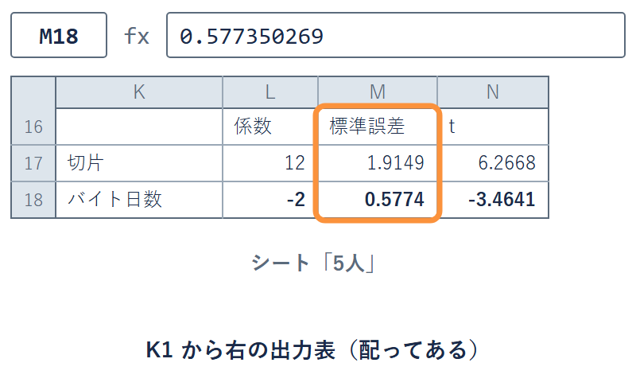

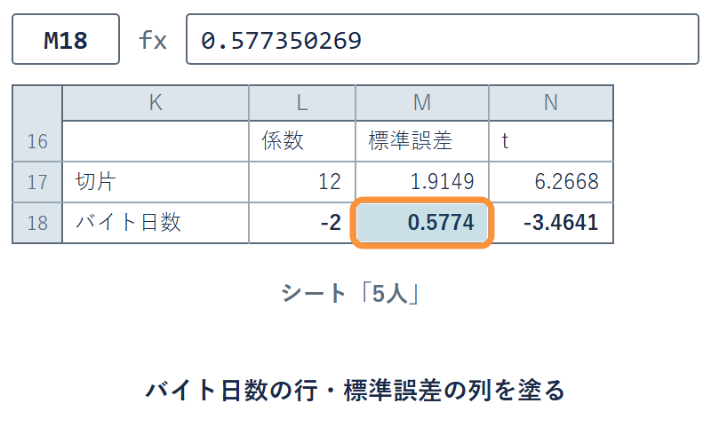

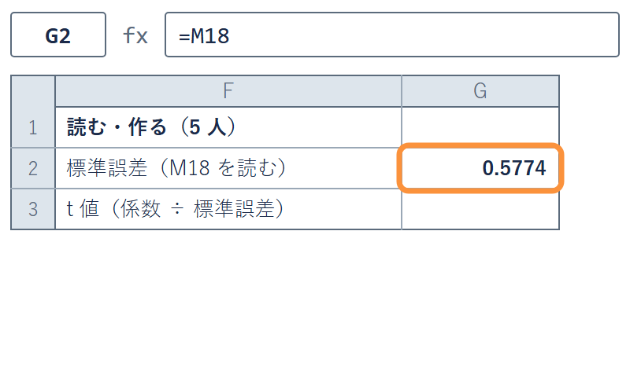

✋ 動画を止めて ①〜③ を進め、0.5774 が出たら再生に戻る

## よくある失敗 標準誤差と傾きの取り違え

**取り違え**  
標準誤差が小さい  
＝ 傾きがゆるい

**正しい読み**  
標準誤差は散らばりの幅  
傾きの大きさとは別

標準誤差が同じ 0.58 でも、傾き −2 の線と傾き −0.1 の線がある  
傾き −0.1 は標準誤差 0.58 より小さく、右下がりかどうかも怪しい

## 36 年の引き直し

- **今度は**：前に出てきた 36 年で、同じように標準誤差を測る
- **困ること**：1991〜2026 年は一度しか起きず、元の線も分からない
- **思考実験**：手元の 36 年を袋に入れ、袋に戻しながら 36 回引く  
  （戻すので、同じ年が 2 回出てもよい）
- **年の組**：選んだ年の失業率と物価上昇率は、組のまま使う

**実データ**：完全失業率（労働力調査）と物価上昇率（消費者物価指数）  
の年平均（2026 年は 1〜5 月の平均）  
lec11-exercise.xlsx「失業率と物価」の A1:C37

## デモ：データを作り直す実験室

数の話

さっきの実験室で、今度は 36 年  
同じ年を何度選んでもよい引き方で選び直し、傾きを 1 つ出す

- **何を見るか**：36 年の傾きの山の幅と、出力表の標準誤差を並べて見る
- **図の意味**：灰の枠はさっきの 5 人の山。右に出力表の標準誤差を足した
- **操作**：さっきと同じ  
  （タブ ①②・1 回・10 回・100 回・1000 回まで・元に戻す）

ミッション 36 年でも、  
山の幅は出力表の標準誤差と同じくらいか

※ 次のスライドへ進むときは、デモの枠の外を一度クリックしてから ← → キーを押す

[interactive chart not shown]

## 5 人と 36 年の標準誤差

| データ | 作り直しの散らばり | 出力表の標準誤差 |
| --- | --- | --- |
| 5 人 （線のまわりで作り直す） | 0.576 | 0.5774 |
| 36 年（年の組を引き直す） | 0.127 | 0.1350 |

どちらも、作り直しの散らばり ≈ 出力表の標準誤差  
36 年は作り方が違うので少しずれる  
5 人と 36 年は単位が違うので、0.576 と 0.127 をそのまま比べはしない

## 36 年の標準誤差の読み

1. **出力表**：「失業率と物価」の  
   K1 から右（配ってある）
2. **印**：完全失業率の行の  
   M18 を薄い色で塗る
3. **読む**：G2 に `=M18` → 0.1350

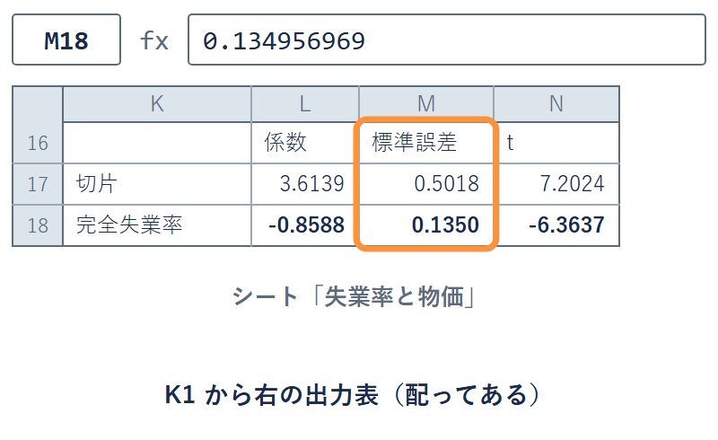

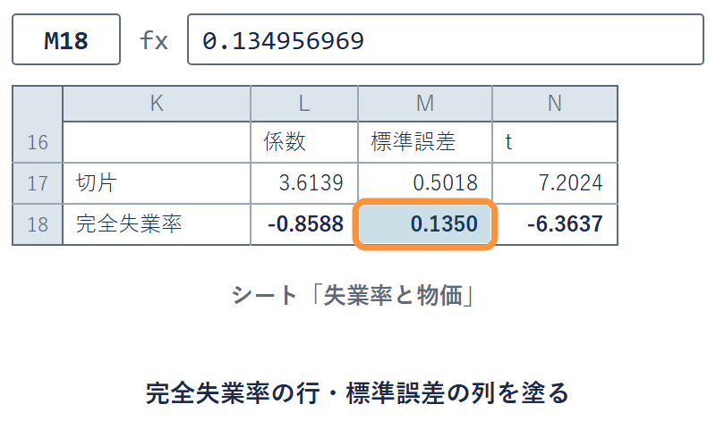

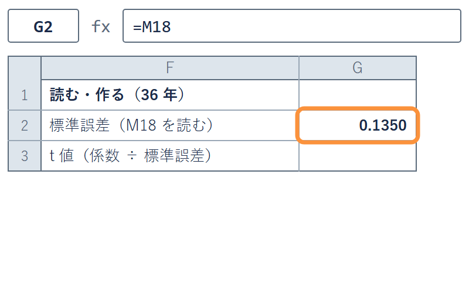

✋ 動画を止めて ①〜③ を進め、0.1350 が出たら再生に戻る

## 演習 11-1 9 年の標準誤差

演習 11-1

1991〜1999 年だけだと、標準誤差は 36 年より大きいか

1. **開く**：「失業率と物価」で  
   データ → データ分析 → 回帰分析
2. **範囲**：Y に C2:C10  
   X に B2:B10・ラベルは外す
3. **出力先**：K21。傾きの行は  
   38 行目（名前は X 値 1）
4. **答え**：M38 を小数第 3 位まで  
   G11 に数字で打つ

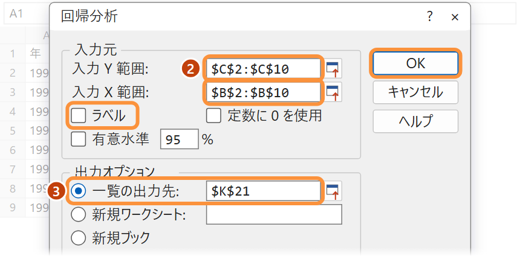

✋ 動画を止めて演習 11-1 を進め、G11 に打ったら再生に戻る

## Q&A 標準誤差

Q1 回帰統計の「標準誤差」1.8257 を読んだ

それは外れの大きさ。**係数の表の、バイト日数の行**（M18）を読む

Q2 出力表が見当たらない

K1 から右に配ってある  
消したら **Y C1:C6・X B1:B6・ラベル・出力先 K1** で出し直す  
（36 年は **Y C1:C37・X B1:B37**）

Q3 期間の出力で、観測数が 9 にならない

範囲は期間の行だけ。**C2:C10 と B2:B10**、ラベルは外す

## まとめ

- **作り直す**：元の線はそのまま、外れだけ引き直す
- **標準誤差**：作り直した傾きの散らばり（5 人 0.576 ≈ 出力表 0.5774）
- **読む所**：係数の表の、バイト日数の行・完全失業率の行

標準誤差は測れた。では傾き −2 は、標準誤差の何個分か  
これを次のトピックで見る

経済データ入門

第11回 — Topic02

t 値

傾きは、標準誤差の何個分？

## この回の道のりと「5人」シート

1

標準誤差

演習 11-1

9 年の標準誤差

2

t 値

演習 11-2

9 年の t 値

3

仮説検定

演習 11-3

7 年の仮説検定

4

信頼区間

演習 11-4

7 年の信頼区間

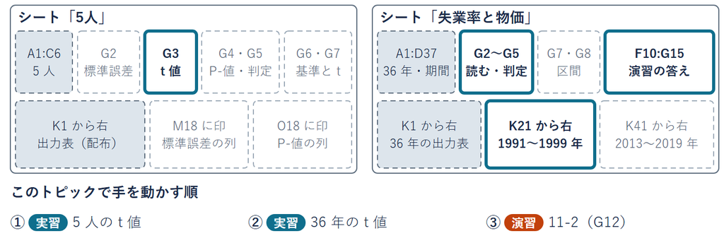

置き場は「5人」の G3、「失業率と物価」の G3 と G12

## 傾きの大きさの物差し

5 人の傾き −2.0 は、標準誤差に埋もれず、0 から離れているか

- **いまの道具**：傾き −2.0 と、標準誤差 0.577
- **足りない所**：−2 は、標準誤差 0.58 の中に埋もれているかもしれない  
  しかも傾きの数は単位で変わる（自習を分で測ると −2.0 × 60 ＝ −120）
- **知りたいこと**：単位に左右されない、0 からの離れ具合
- **そこで**：標準誤差 1 個分を物差しにして、0 から何個分かを数える

## 基準の傾き 0

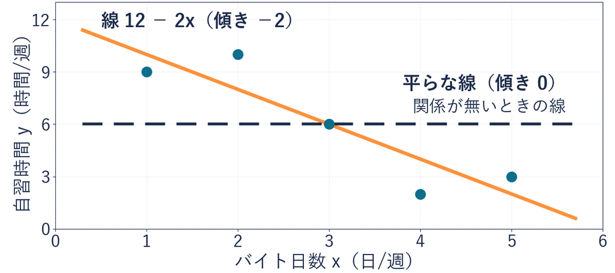

基準＝比べる相手の傾き。まず平らな線の傾き 0 と比べる  
線の高さは自習時間の平均 6。大事なのは傾き 0

## 標準誤差の個数の数え方

手順

STEP 1傾きを読む

STEP 2標準誤差を読む

STEP 3傾きから基準を引き、標準誤差で割る

割ると「標準誤差の何個分」になる。  
標準誤差も傾きと同じ単位なので、単位が消える

## 標準誤差 1 個分で測る距離

[figure not shown]

標準誤差 1 個分（0.577）を 3 つ置いても −2.  
0 に届かない。3.46 個分

## たしかめ 分で測った個数

自習を分で測り直すと、傾きは 60 倍の −120  
標準誤差の何個分になるか

**1 3.46 個分のまま**

**2 60 倍に増える**

**3 1/60 に減る**

1 つ決めてから先へ。答えは、このトピックの中で出す

## 分で測った標準誤差 1 個分

[figure not shown]

標準誤差も 60 倍で 0.577 × 60 ≈ 34.6。割ると同じ 3.46 個分。  
たしかめの答えは 1 番

## t 値

**t 値：傾きが基準から、標準誤差の何個分離れているか**

定義

$$\textbf{t 値} = (\textbf{傾き} - \textbf{基準}) \div \textbf{標準誤差}$$

今回は

$(-2.0 - 0) \div 0.5774$

$\approx -3.46$

基準は 0

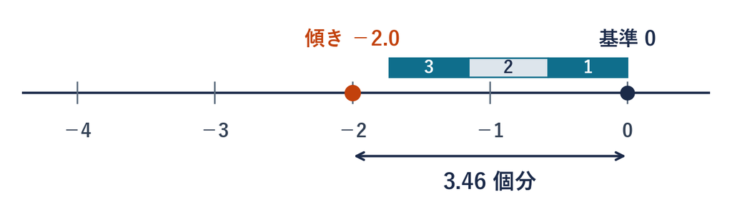

「2 時間減る」は、標準誤差 0.58 時間の 3.46 個分、0 から離れている

## t 値の符号と大きさ

- **符号**：マイナスは、傾きが 0 より小さい（右下がりの線）という向き
- **大きさ**：基準からの離れ具合
- **単位**：時間で測っても分で測っても、同じ数
- **何個分なら**：偶然とは考えにくいと言えるか。それはこのあと

## よくある失敗 急な傾きと t の取り違え

**取り違え**  
傾きが急なら  
t も大きい

**正しい読み**  
同じ −2.0 でも  
標準誤差 0.5 なら −4.0  
標準誤差 2.0 なら −1.0

t は、傾きと標準誤差の両方で決まる

## 5 人の t 値の式

1. **読む**：係数 L18 と  
   標準誤差 M18
2. **式**：G3 に `=L18/M18` → −3.4641  
   （基準 0 なので引き算は省く）
3. **比べる**：出力表の t（N18）と  
   小数第 4 位まで同じ

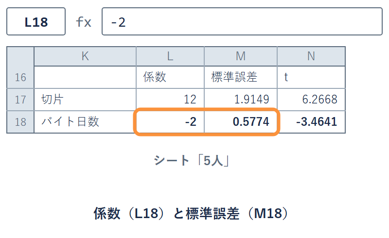

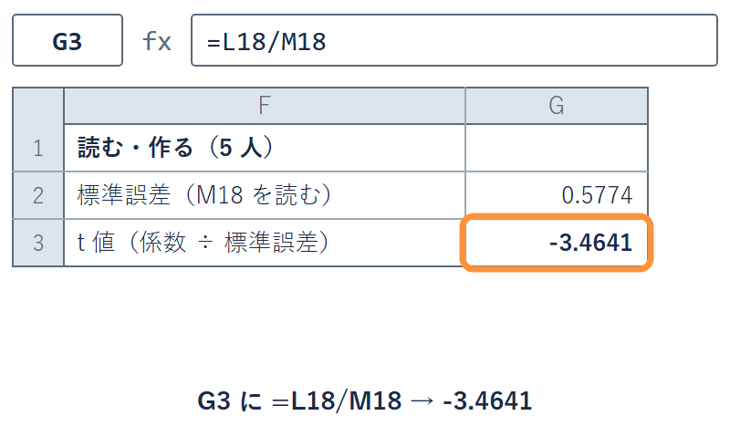

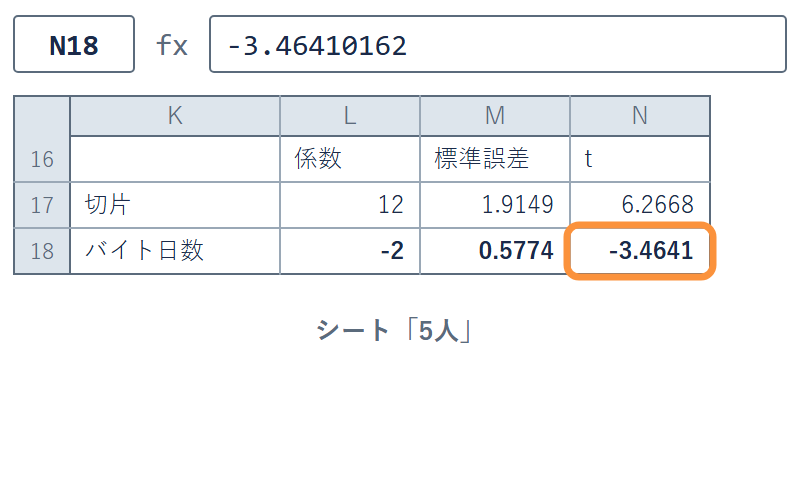

✋ 動画を止めて ①〜③ を進め、−3.4641 が出たら再生に戻る

## 36 年の t 値

[figure not shown]

今度は 36 年。(−0.859 − 0) ÷ 0.135 ≈ −6.36（出力表の t も −6.3637）  
「0.86 ポイント低い」は、標準誤差の 6 個分以上 0 から遠い

## 傾きの数と標準誤差の個数

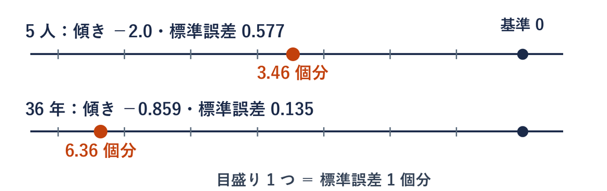

傾きのままでは単位が違って比べられない。  
標準誤差で割ると単位が消え  
並べて比べられる。比べると 36 年のほうが 0 から遠い

## 36 年の t 値の式

1. **読む**：「失業率と物価」の  
   L18 と M18
2. **式**：G3 に `=L18/M18`  
   → −6.3637
3. **比べる**：出力表の t（N18）と  
   小数第 4 位まで同じ

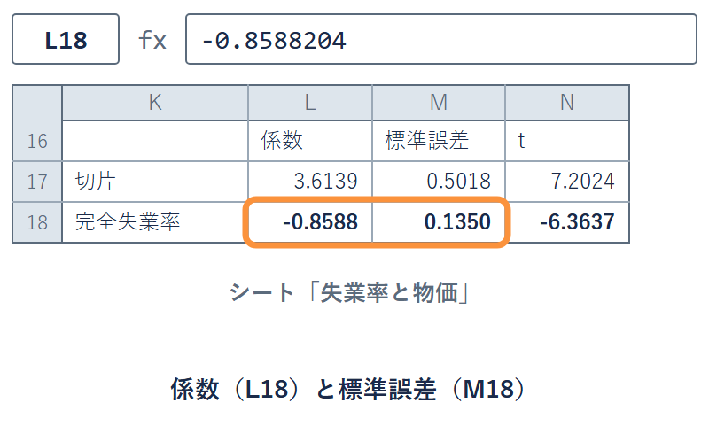

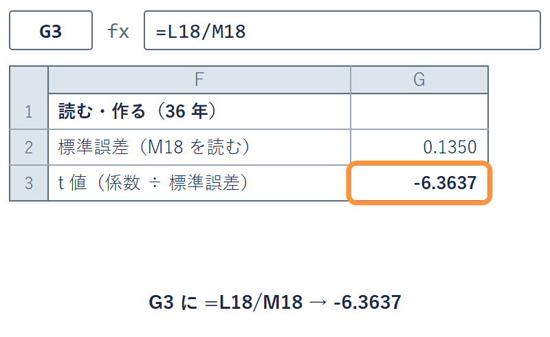

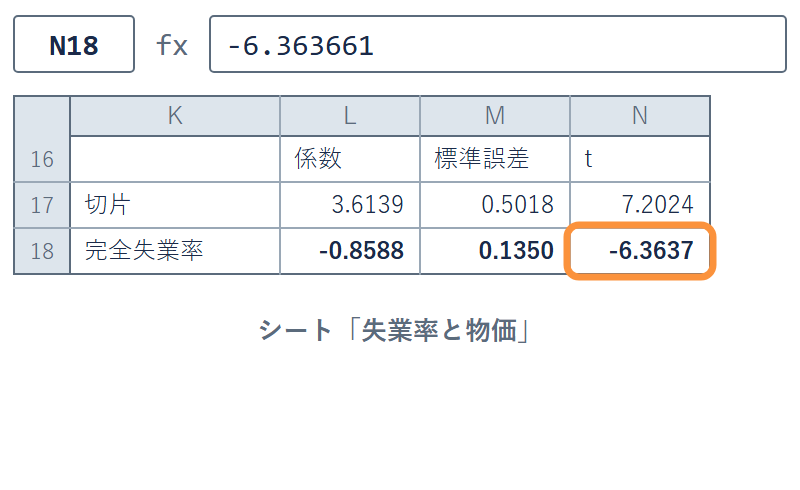

✋ 動画を止めて ①〜③ を進め、−6.3637 が出たら再生に戻る

## 演習 11-2 9 年の t 値

演習 11-2

1991〜1999 年の傾きは、標準誤差の何個分か

1. **出力表**：演習 11-1 で K21 から右に出した表（**実データ** 1991〜1999 年）
2. **式**：G12 に `=L38/M38`（基準 0 なので引き算は省く）
3. **比べる**：出力表の t（N38）と同じか
4. **答え**：G12 の式が答え。36 年の −6.36 より 0 に近いか見る

✋ 動画を止めて演習 11-2 を進め、G12 が出たら再生に戻る

## Q&A t 値

Q1 G3 が、出力表の t と大きく違う

切片の行（17 行目）で割っている。**18 行目**（傾きの行）を使う

Q2 t がマイナスになった

右下がりという向きを表すだけ。離れ具合は**大きさ**で見る

Q3 出力表の t と、最後の桁が違う

丸めた数を打った。**セルを参照**して割る  
N18 は桁が多く出るだけ。小数第 4 位まで同じなら合っている

## まとめ

- **基準**：比べる相手の傾き。まず 0（関係が無いときの傾き）
- **t 値**：（傾き − 基準）÷ 標準誤差
- **5 人と 36 年**：−3.46 と −6.36。36 年のほうが 0 から遠い
- **単位**：時間でも分でも、t は変わらない

何個分離れていれば「偶然とは考えにくい」と言えるか  
これを次のトピックで見る

経済データ入門

第11回 — Topic03

仮説検定

この傾きは、偶然だけで説明できる？

## この回の道のりと「5人」シート

1

標準誤差

演習 11-1

9 年の標準誤差

2

t 値

演習 11-2

9 年の t 値

3

仮説検定

演習 11-3

7 年の仮説検定

4

信頼区間

演習 11-4

7 年の信頼区間

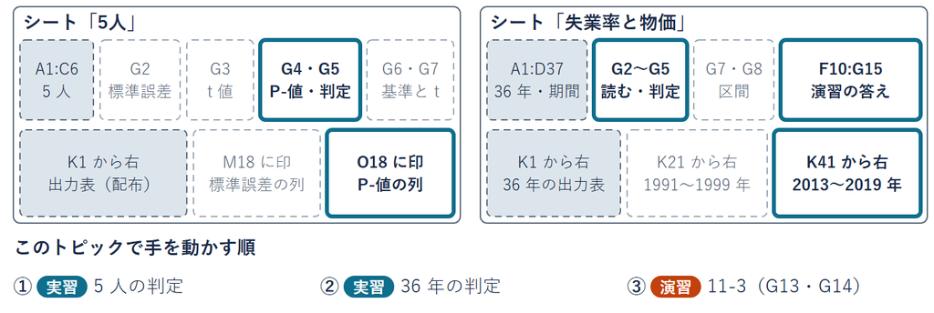

置き場は「5人」の G4・G5、「失業率と物価」の G4・G5 と G13・G14

## 疑う人の言い分

**標準誤差の 3.46 個分は、たまたまでも出る離れ具合か**

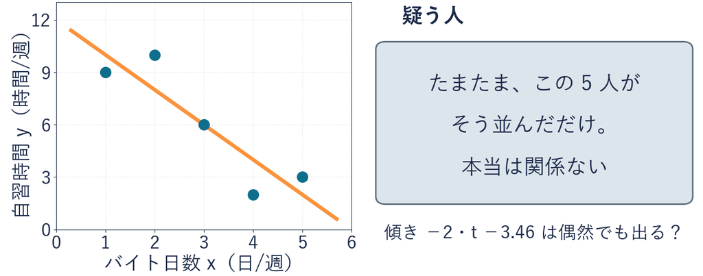

## 言い分を認めた世界

- **正面からは**：手元のデータ 1 組だけで  
  「関係はある」と言い切るのは難しい
- **代わりに**：疑う人の言い分を、いったん認める
- **数える**：本当に関係が無い世界で、手元の結果がどれほど出るか
- **めったに出ないなら**：言い分のほうに無理がある

世界の作り方は、前に出てきた、  
線のまわりで外れだけ引き直す作り直しと同じ  
今度は、線を平らにする

## 仮説検定の 3 段

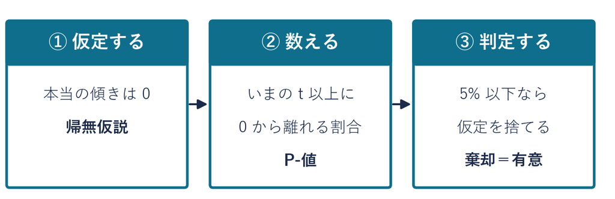

この 3 段の流れを、仮説検定と呼ぶ  
名前は 3 つ：帰無仮説・P-値・棄却（有意）

## 関係なしの世界の 5 人

[figure not shown]

① 仮定する：平らな線（高さは平均 6）のまわりで、  
外れだけ引き直し、毎回 t を出し直す  
外れの大きさは手元と同じ 1.826  
（出力表の回帰統計の「標準誤差」）

## たしかめ 関係なしの世界の t

関係なしの世界で、5 人を 1000 回作り直す  
t が −3.46 より左か、+3.46 より右に出るのは何回くらいか  
疑う人は向きを言っていないので、右側も数える

**1 約 4 回**

**2 約 40 回**

**3 約 400 回**

1 つ決めてから先へ。答えは、このトピックの中で出す

## 外側に出た回数

[figure not shown]

② 数える：外側は左 20 回・右 21 回で 41 回。  
たしかめの答えは 2 番

## 5% との比較

割合

$41 \div 1000$

$\approx 0.041$

外側に出た割合

比べる

$0.041 \leqq 0.05$

5% 以下

5%＝20 回に 1 回。これより珍しければ「たまたま」では説明しにくい  
と、前もって決めておく線（多くの分野で使う）

③ 判定する：仮定を捨てる。この 5 人では、関係が無いとは考えにくい

## 出力表の P-値

[figure not shown]

バイト日数の行の P-値は 0.0405  
Excel は 1000 回作らずに、山の外側の割合を式で出す

## 仮説検定

**仮説検定：「関係なし」と仮定して、いまの結果の珍しさを測る**

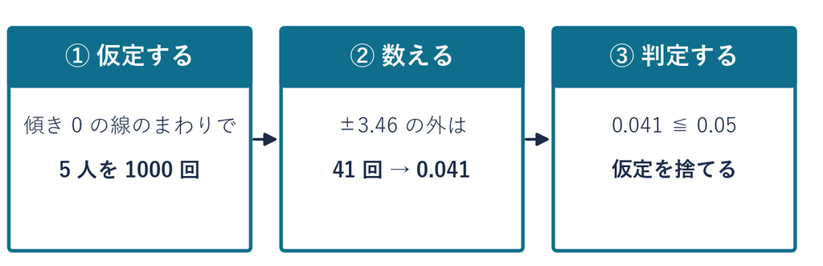

## 仮説検定の用語

用語

**帰無仮説**疑う人の「本当は関係ない」（傾きは 0）

**P-値**その世界で、いまの t（±3.46）と同じか  
それより 0 から離れた t が出る割合

**棄却**たまたまでは説明しにくいので、疑いを退ける

**有意**棄却したこと。5% は広く使われる慣習の線

## よくある失敗 P-値の向き

**取り違え**  
P-値 0.041 ＝  
関係が無い確率 4.1%

**正しい読み**  
関係が無い世界で作り直すと  
±3.46 の外の t が  
1000 回に 41 回くらい

「関係なし」が正しいと決めてから数えた割合。だから  
「関係なし」が正しい確率は、この計算のどこにも出てこない

## 5 人の P-値と判定

1. **読む**：P-値の列  
   （傾きの行の O18）
2. **印**：O18 を薄い色で塗る
3. **判定**：G4 に `=O18`、G5 に  
   「0.0405 は 0.05 以下なので  
   捨てる（有意）」と打つ

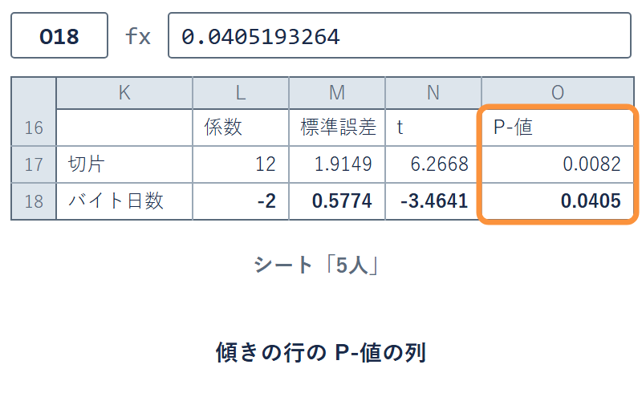

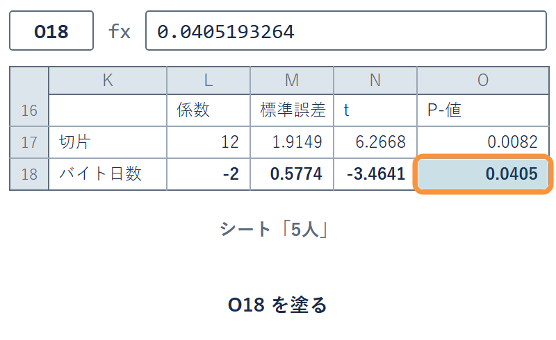

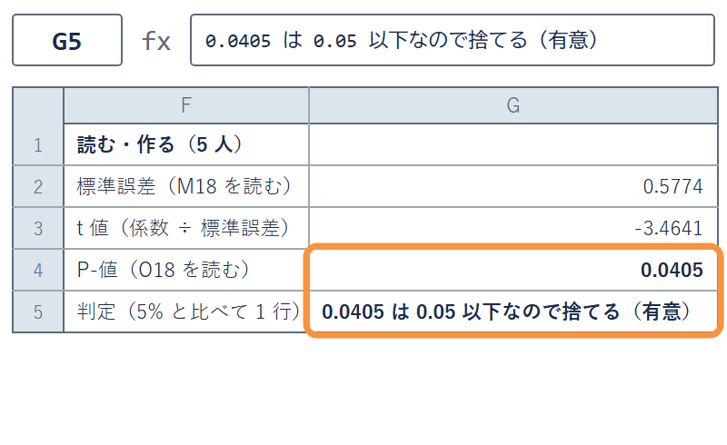

✋ 動画を止めて ①〜③ を進め、判定を書いたら再生に戻る

## 何本も試す罠

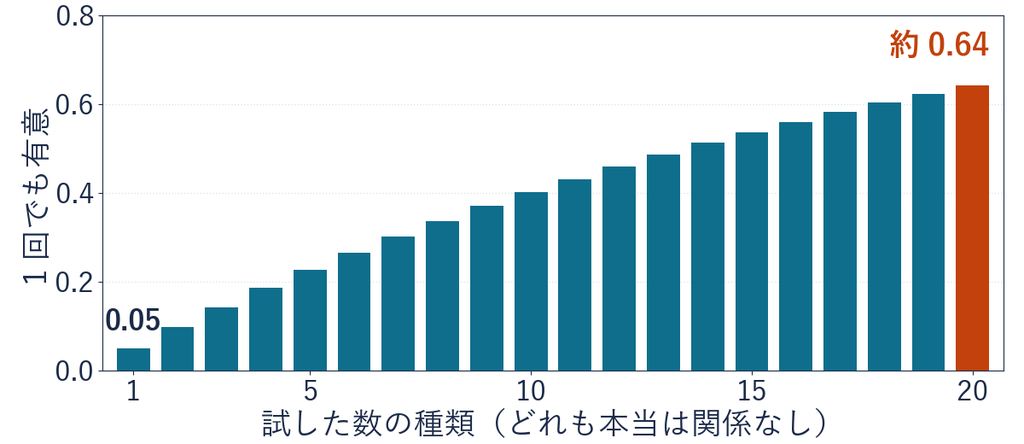

関係の無いもの（靴のサイズなど）を 20 種類別々に試すと  
どれかが「有意」になるのは約 0.64  
どれも有意にならないのは、0.95 を 20 回掛けた約 0.36

## 36 年の関係なしの世界

[figure not shown]

今度は 36 年で同じ 3 段  
−6.36 より離れたのは 0 回（いちばん遠くて 3.47）

## 36 年の P-値と目安の 2

- **出力表の P-値**：2.91478E-07（＝0.000000291…）。  
  5% よりずっと小さいので、仮定を捨てる
- **目安の 2**：±2 の外は 1000 回で 53 回。点がある程度多いとき、  
  t の大きさ 2 が 5% のおよその目安
- **有意 ≠ 重要**：偶然では説明しにくい、というだけ
- **大きさは別**：失業率が 1 ポイント高い年は、  
  物価上昇率が約 0.86 ポイント低い  
  この大きさが大事かどうかは、P-値は答えない

## 36 年の P-値と判定

1. **読む**：P-値の列  
   （完全失業率の行の O18）
2. **印**：O18 を薄い色で塗る
3. **判定**：G4 に `=O18`、G5 に  
   「2.91E-07 は 0.05 以下なので  
   捨てる（有意）」と打つ

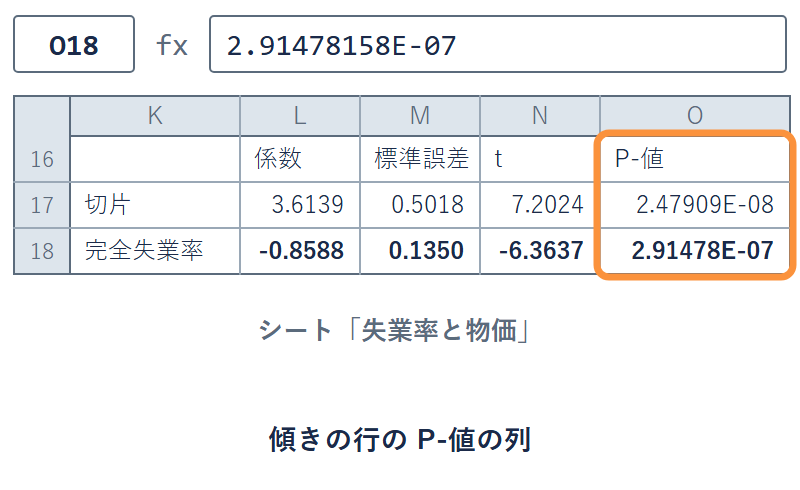

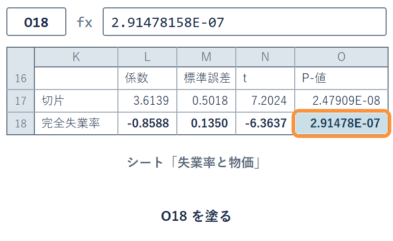

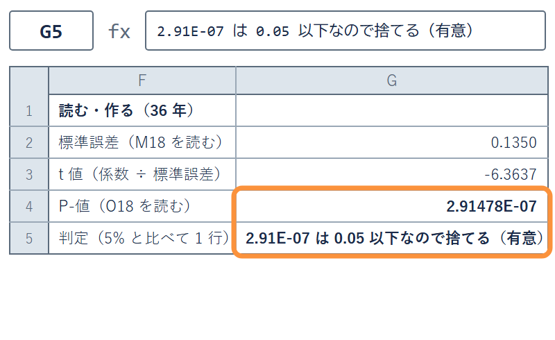

36 年は年どうしの外れが似やすいので、  
この P-値は表示よりいくらか割り引いて読む（詳しくは配布資料の付録 2）

✋ 動画を止めて ①〜③ を進め、判定を書いたら再生に戻る

## 演習 11-3 7 年の仮説検定

演習 11-3

2013〜2019 年の 7 年だけで、関係なしを捨てられるか

1. **開く**：「失業率と物価」で  
   データ → データ分析 → 回帰分析
2. **範囲**：Y に C24:C30  
   X に B24:B30・ラベルは外す
3. **出力先**：K41。傾きの行は  
   58 行目（名前は X 値 1）
4. **答え**：P-値 O58 を G13 に  
   5% と比べた判定の 1 行を G14 に

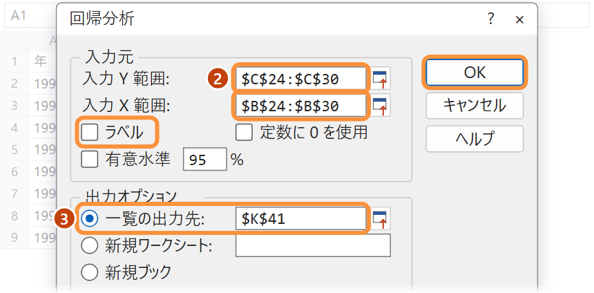

✋ 動画を止めて演習 11-3 を進め、G13 と G14 を書いたら再生に戻る

## 3 つのデータの判定

| データ | t | P-値 | 判定 |
| --- | --- | --- | --- |
| 5 人 | −3.46 | 0.0405 | 捨てる（有意） |
| 36 年 | −6.36 | 2.91478E-07 | 捨てる（有意） |
| 2013〜2019 年 | −0.31 | 0.767 | 捨てない |

捨てない ＝ この 7 年では、偶然と区別できなかった  
関係が無いと分かったわけではない

## Q&A 仮説検定

Q1 P-値が 2.91478E-07 と出た

エラーではない。小数点を左へ 7 つずらす＝**0.000000291…**

Q2 切片の行の P-値で判定した

切片の行は別の問い。**傾きの行**  
（18 行目・演習 11-3 の表は 58 行目）を読む

Q3 捨てないなら、関係は無いのか

言えない。**このデータでは区別できなかった**まで

## まとめ

- **仮説検定**：① 仮定する ② 数える ③ 判定する
- **5 人**：外側 41 回 ≈ 0.041。5% 以下なので捨てる
- **捨てない**：このデータでは偶然と区別できなかった  
  （関係が無いとは言えない）
- **P-値の向き**：関係なしを仮定してから数えた割合
- **罠**：何本も試すと、どれかは有意になる

0 は捨てた。では傾きは −1 くらいか、−3 くらいか  
これを次のトピックで見る

経済データ入門

第11回 — Topic04

信頼区間

傾きを幅で言う

## この回の道のりと「5人」シート

1

標準誤差

演習 11-1

9 年の標準誤差

2

t 値

演習 11-2

9 年の t 値

3

仮説検定

演習 11-3

7 年の仮説検定

4

信頼区間

演習 11-4

7 年の信頼区間

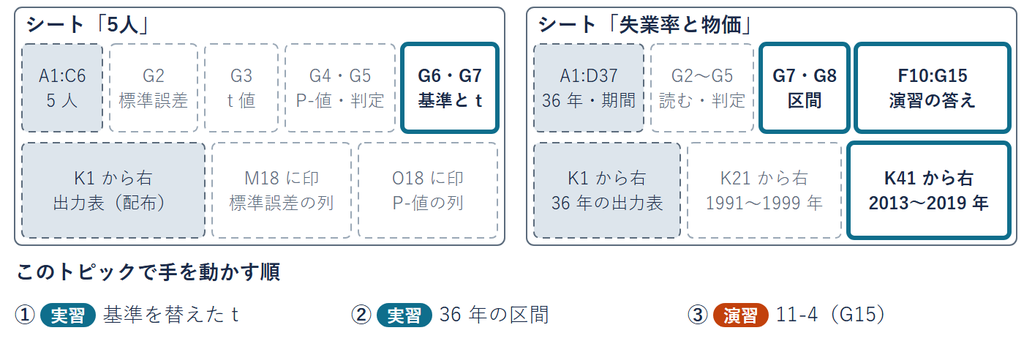

置き場は「5人」の G6・G7、「失業率と物価」の G7・G8 と G15

## 0 以外の基準

5 人の傾き −2.0 は「0 ではない」と言えた。でも  
バイト 1 日で自習が 1 時間減るのか、3 時間減るのか

- **いまの道具**：基準 0 を仮定して、5% で判定した
- **足りない所**：傾きの大きさの見当がつかない
- **知りたいこと**：本当の傾きが −1 なら？ −5 なら？
- **そこで**：t の式の基準を 0 以外に替えて、同じ判定をする

## 5 人の境 3.18

[figure not shown]

±3.18 の外は、左右を合わせて 49 回 ≈ 5%。これが 5 人の境

## 基準を替えた判定

手順

STEP 1基準（本当の傾きの候補）を決める

STEP 2t ＝（−2.0 − 基準）÷ 0.5774

STEP 3t の大きさ（＋−を外した数）が  
3.18 以内なら ○（捨てない）、超えたら ×

3.18 は Excel が点の数に合わせて使う境。点が少ないほど大きい  
t の大きさが 3.18 を超える ＝ P-値が 5% 以下  
（同じ判定を t の側で言ったもの）  
基準を替えても、  
作り直した t の山の形は同じ。だから境も同じ 3.18

## 3 つの基準の t 値

基準 −1

$(-2.0 - (-1)) \div 0.5774$

$\approx -1.73$

○ 捨てない

基準 0

$(-2.0 - 0) \div 0.5774$

$\approx -3.46$

× 捨てる

基準 −5

$(-2.0 - (-5)) \div 0.5774$

$\approx +5.20$

× 捨てる

基準 0 の × は、仮説検定と同じ判定

## ○ が並ぶ範囲

[figure not shown]

基準を細かく替えると、○ が並ぶのは −3.84〜−0.16

## 信頼区間

**信頼区間：データと食い違わない傾きを、幅で言う**

定義

$$\textbf{95\% 信頼区間} = \textbf{係数} \pm \textbf{境} \times \textbf{標準誤差}$$

境目

$(-2.0 - \textbf{基準}) \div 0.5774$

$= \pm 3.18$

境目の基準を解く

今回は

$\textbf{基準}$

$= -2.0 \pm 3.18 \times 0.5774$

5 人

−3.84〜−0.16。5% で捨てられない基準の集まりなので 95%（100% − 5%）